# r4d_HHSurvey_DataImputation.rds

Biraj Adhikari

2023-05-01

# Imputation of missing values

Also referred to as : “gap-filling”

Paper taken as reference for algorithm: Stekhoven et al. 2012 https://doi.org/10.1093/bioinformatics/btr597 Paper that shows the algorithm does the job: Penone et al. 2014 doi: 10.1111/2041-210X.12232

## Requirements

```r
library(dplyr)
```

```r
library(missForest)
library(visdat) # to show missing values in a plot
library(polycor) # for the hetcor function
library(corrplot) # to visualise the correlations
library(data.table)
library(ggplot2)
library(cowplot)

#TODO select the option below
variables_to_include <- "explanatory"
#variables_to_include <- "response"
```

This script is heavily based on the following script (written by N. Schenk based on scripts from C. Penone) : https://github.com/allanecology/BetaDivMultifun/blob/master/vignettes/function_imputation.Rmd

## Data preparation

The dataset ’r4d_CleanData_HouseholdNepal.rds”, obtained from “r4d_HHSurvey_DataCleaning.rmd”, where we cleaned the raw data is used for imputation.

Additionally, we impute response and explanatory variables separately. We have also included a lot of other variables from the household survey which we do not use in the mansucript, or in the analysis to enhance imputation quality.

Separating explanatory and response variables

```r
maindata = readRDS("r4d_CleanData_HouseholdNepal.rds")

explanatory_variables <- strsplit("Location, Caste, House.Material, Gender, Age, Farmpc, Occupation, Nature, Ladder, EnoughFood, EnoughIncome, LandPrice, tlu, Healthy, WaterShortage, EnergySuff, ElectricitySuff, Education, Drr", split = ", ")[[1]]

#making a separate list for auxillary variables, just in case we might need them later:
aux_variables <-strsplit("AgriTrends, AgroDiversity, ForestArea, ForestQuality, ForestWildlife, FreshwaterQual, FreshwaterQuant, FreshwaterWildlife, FoodTrends, IncomeTrends, WaterTrends, EnergyTrends, Electricity, ElectricityTrends, EducationTrends, DrrTrends, HealthCheck_Hospital, HealthCheck_Aayurved, HealthCheck_Homemade, HealthCheck_Pharmacy, HealthCheck_Dhami, WaterSource_Tap, WaterSource_River, WaterSource_Tube, WaterSource_Lake, WaterSource_Spring, WaterSource_Well, WaterSource_Others, EnvEducation_School, EnvEducation_Media, EnvEducation_Fam, EnvEducation_Elders, EnvEducation_NGO, EnvEducation_Others, ConservationNature, ConservationPeople", split = ", ")[[1]]

#adding explanatory and auxillary variables together to use for imputation
explanatory_variables <- c(explanatory_variables, aux_variables)

response_variables <- strsplit("NatureFood + NatureWork + NatureHealth + NatureWater + NatureEnergy + NatureEducation + NatureDrr + NatureRecrea + NatureCulture", split = " [+] ")[[1]]

maindata_explanatory_variables <- maindata[, explanatory_variables]
maindata_response_variables <- maindata[, response_variables]

rm(explanatory_variables)
rm(response_variables)
rm(aux_variables)
rm(maindata)
```

```r
if(variables_to_include == "explanatory"){
  dataset_raw <- maindata_explanatory_variables # rename dataset --> no confusion and easy to chose another dataset
} else if(variables_to_include == "response"){
  dataset_raw <- maindata_response_variables # rename dataset --> no confusion and easy to chose another dataset
}
rm(maindata_explanatory_variables, maindata_response_variables)

str(dataset_raw)
```

```
## 'data.frame':    572 obs. of  55 variables:
##  $ Location            : Factor w/ 3 levels "Bahundangi","Sulubung",..: 2 2 2 2 2 2 2 2 2 2 ...
##  $ Caste               : Factor w/ 3 levels "Ethnic","Higher",..: 1 1 1 1 2 2 1 1 1 1 ...
##  $ House.Material      : Factor w/ 2 levels "Cement/Bricks/Concrete/Wood",..: 2 1 1 2 1 1 2 1 2 2 ...
##  $ Gender              : Factor w/ 2 levels "Female","Male": 1 1 1 2 2 2 1 1 2 2 ...
##  $ Age                 : int  23 32 33 30 43 40 26 59 38 55 ...
##  $ Farmpc              : int  30 40 40 60 30 40 40 45 35 30 ...
##  $ Occupation          : Factor w/ 5 levels "Agriculture",..: 1 1 1 2 1 1 1 1 1 1 ...
##  $ Nature              : Factor w/ 5 levels "Non-Living","Living",..: 2 1 2 1 2 1 2 2 1 2 ...
##  $ Ladder              : int  8 6 4 6 5 4 10 7 5 5 ...
##  $ EnoughFood          : Factor w/ 2 levels "Yes","No": 2 2 2 1 1 1 2 2 2 1 ...
##  $ EnoughIncome        : Factor w/ 5 levels "Very sufficient",..: 5 2 2 2 2 2 5 2 2 4 ...
##  $ LandPrice           : num  102000 30000 62000 62000 204000 224000 102000 40000 62000 152000 ...
##  $ tlu                 : num  2 1.1 2.7 0.4 1.4 1.7 0.7 0.9 3.1 0.9 ...
##  $ Healthy             : Factor w/ 4 levels "Very healthy",..: 2 3 3 2 2 3 3 3 2 2 ...
```

[output cut: 41 more lines]

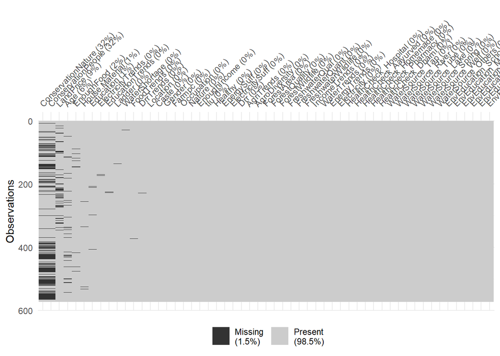

```r
visdat::vis_miss(dataset_raw, sort_miss = T)
```

Cleaning out variables with too many missing values, i.e. with more than 20% of missing values. Note that our recommendation is to perform the imputation even if > 20% are missing, but carefully check the imputation error and exclude the variables if the imputation error is too high.

Below : code to exclude variables with > 20% missing values

```r
threshold <- 0.2
t <- apply(dataset_raw, 2, function(x) sum(is.na(x)))
exclude <- names(which(t > nrow(dataset_raw) * threshold))
dataset_raw <- dataset_raw[, !colnames(dataset_raw) %in% exclude]
rm(t); rm(exclude); rm(threshold)
```

## Check Correlations

Identify numeric variables

```r
# create dataset with only numeric variables
#note: no numeric data for response variables
corrdataset_raw <- dataset_raw[, colnames(dataset_raw)[sapply(dataset_raw, is.numeric)]]
```

Since our dataset is mixed type, we perform correlation using hetcor (pearson, polyserial and polychoric correlation)  
- pearson correlation between 2 numeric variables  
- polyserial correlations between numeric and ordinal variables  
- polychoric correlations between ordinal variables

```r
dataset_raw <- as.data.frame(dataset_raw)
maindata_cor <- hetcor(dataset_raw, use = "pairwise.complete.obs") # takes some time

# we use complete observations. Therefore, each one to one correlation is based on all available rows (observations). The number of observations thus potentially differs for each comparison

#    we can check the number of observations the given correlation is based on
corrplot(maindata_cor$n, method = "circle", type = "lower",
         tl.col = "black", tl.srt = 45, diag = F, order = "original", is.corr = F)
#
corrplot(maindata_cor$correlations, method = "circle", type = "lower",
         tl.col = "black", tl.srt = 45, diag = T, tl.cex = 0.4)

#    as rule of thumb, no explanatory variables in the same model should have a correlation of higher than 0.7. Here that would mean : no case with correlation > 0.7

thres <- 0.7
highcorr <- maindata_cor$correlations
highcorr[highcorr < thres & highcorr > -thres] <- 0
corrplot(highcorr, method = "circle", type = "lower",
         tl.col = "black", tl.srt = 45, diag = F, tl.cex = 0.4)

dev.off() # to remove hetcorr specific plotting window
```

```r
rm(highcorr, thres)
```

## Log transformation and removal of negative

before changing values, store the original dataset

```r
dataset_raw_backup <- data.table::copy(dataset_raw)
corrdataset_raw <- data.table::data.table(corrdataset_raw) # change to data.table class (code used data.table, not data.frame)
```

remove negative values in the numeric variables, remember to add again after imputation! find negative values

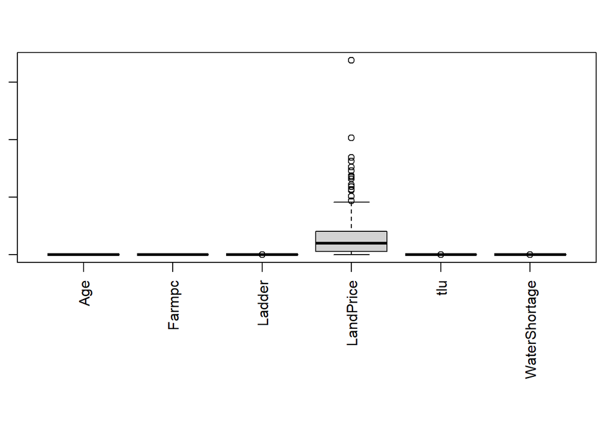

```r
par(mar = c(10, 1, 3, 1))
boxplot(corrdataset_raw, las=2)
```

```r
# minimum of the numeric columns
negative <- colnames(corrdataset_raw)[which(corrdataset_raw[, lapply(.SD, function(x) min(x, na.rm=T))] < 0)]

if(length(negative) == 0){
  print("no negative values to exclude")
} else if(length(negative) > 0){
  print(paste("need to shift", length(negative), "negative values. Please run and adapt code chunk below."))
}
```

```
## [1] "no negative values to exclude"
```

There are no negative values, so the dataframe remains unchanged.

Log transformation of the numeric columns. The natural logartithm of values smaller than 1 is negative. Therefore, all values are shifted by 1 again to avoid any negative values in the log transformed dataset.

```r
dataset_raw <- data.table(dataset_raw) # convert to class data.table, from now on, this package is used for data wrangling
numcols <- colnames(dataset_raw)[sapply(dataset_raw, is.numeric)]
dataset_raw[, (numcols) := lapply(.SD, as.numeric), .SDcols = numcols]
# log transform the values + 1, later shift them back.
dataset_raw[, (numcols) := lapply(.SD, function(x) log(x+1)), .SDcols = numcols]

# record NA value positions for visualistation
naloc <- is.na(dataset_raw)
```

## Imputation

The imputation is repeated 50 times, and the mean of the imputed values is taken for numeric variables, and the most freqently classifed level is taken for categorical variables.

### Tuning mtry paramteter

By default square root of p = number of columns. Try values between 2 and 50 to tune the OOB error. Find the minimum of error and use the according mtry parameter value.

source script : https://github.com/eric-allan/BE.RE.analysis/blob/master/EF_select_suitable_functions.R by Caterina Penone

```r
# note : only run once, then work with the output dataset.
maxiteration <- ifelse(variables_to_include == "explanatory", 50, 9)
sqrt(ncol(dataset_raw))
OOB_NRMSE <- c()
i <- 1
for (mtry in 2:maxiteration) {
   imp.matX <- missForest(dataset_raw, mtry = mtry) #default variablewise = FALSE

   OOB_NRMSE[i] <- imp.matX$OOBerror[1]
   i <- i + 1
   print(i)
}
#note: for response variable, there is no NRMSE (since everything is categorical)
#so, we are actually comparing the PFC, not NRMSE. But the code is the same to make it less complicated.

if(variables_to_include == "explanatory"){
saveRDS(OOB_NRMSE, file = "ImputationResults/TunedParams/tune_mtry_OOB_NRMSE_explanatory.rds")
}

if(variables_to_include == "response"){
saveRDS(OOB_NRMSE, file = "ImputationResults/TunedParams/tune_mtry_OOB_NRMSE_response.rds")
}

rm(i)
```

The following code visualizes mtry optimization

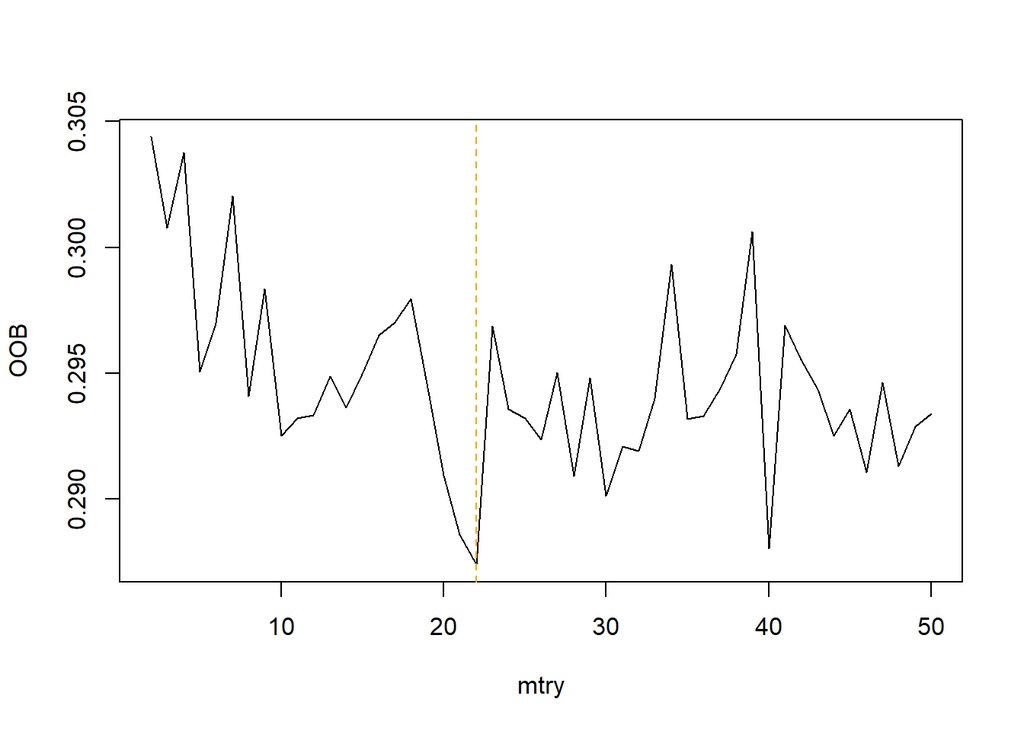

```r
maxiteration <- ifelse(variables_to_include == "explanatory", 50, 9)

if(variables_to_include == "explanatory"){
  OOB_NRMSE <- readRDS(file = "ImputationResults/TunedParams/tune_mtry_OOB_NRMSE_explanatory.rds")
}
if(variables_to_include == "response"){
  OOB_NRMSE <- readRDS(file = "ImputationResults/TunedParams/tune_mtry_OOB_NRMSE_response.rds")
}

plot(seq(2, maxiteration), OOB_NRMSE, type = "l", ylab = "OOB",
     xlab = "mtry")
abline(v = which(OOB_NRMSE == min(OOB_NRMSE)) + 1, lty = "dashed", col = "orange")
```

```r
which(OOB_NRMSE == min(OOB_NRMSE)) + 1 # optimal mtry is 22 for explanatory and 3 for response
```

```
## [1] 22
```

```r
rm(maxiteration)
```

Explanatory : use mtry = 22 Response : use mtry = 3

### Tuning ntree paramteter

default is 100, increasing ntree can decrease the imputation error. source script : https://github.com/eric-allan/BE.RE.analysis/blob/master/EF_select_suitable_functions.R by Caterina Penone

```r
mtry_val = ifelse(variables_to_include == "explanatory", 22, 3)

OOB_NRMSE <- c()
i <- 1
for (ntree in c(100, 110, 120, 130, 180, 200)) {
   imp.matX <- missForest(dataset_raw, mtry = mtry_val, ntree = ntree)
   OOB_NRMSE[i] <- imp.matX$OOBerror[1]
   i <- i + 1
   print(i)
}
OOB_NRMSE <- data.table(ntree = c(100, 110, 120, 130, 180, 200), OOB = OOB_NRMSE)

if(variables_to_include == "explanatory"){
saveRDS(OOB_NRMSE, file = "ImputationResults/TunedParams/tune_ntree_OOB_NRMSE_explanatory.rds")
}
if(variables_to_include == "response"){
saveRDS(OOB_NRMSE, file = "ImputationResults/TunedParams/tune_ntree_OOB_NRMSE_response.rds")
}

rm(i); rm(ntree)
```

Visualize

```r
if(variables_to_include == "explanatory"){
  OOB_NRMSE <- readRDS(file = "ImputationResults/TunedParams/tune_ntree_OOB_NRMSE_explanatory.rds")
}
if(variables_to_include == "response"){
  OOB_NRMSE <- readRDS(file = "ImputationResults/TunedParams/tune_ntree_OOB_NRMSE_response.rds")
}

OOB_NRMSE[which(OOB_NRMSE$OOB == min(OOB_NRMSE$OOB)), ntree] # 120 for explanatory
```

```
## [1] 120
```

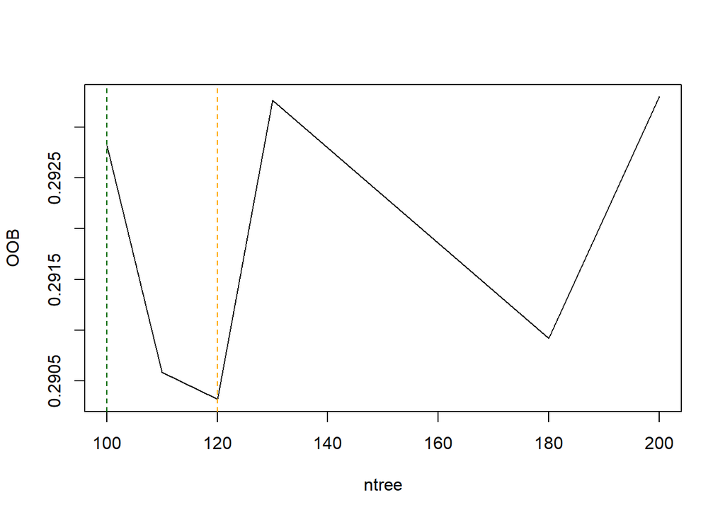

```r
plot(OOB_NRMSE$ntree, OOB_NRMSE$OOB, type = "l", ylab = "OOB",
     xlab = "ntree")
abline(v = OOB_NRMSE[which(OOB_NRMSE$OOB == min(OOB_NRMSE$OOB)), ntree], lty = "dashed", col = "orange")
abline(v = 100, lty = "dashed", col = "darkgreen")
```

Explanatory variables : stay with ntree = 100 (120 is not really better)  
Response variables: Stay with ntree = 100

### Actual Imputation

```r
# 50 imputations
impvals <- list()
imperr <- list()
dataset <- dataset_raw
```

```r
mtry_val = ifelse(variables_to_include == "explanatory", 22, 3)
#ntree is 100 for both explanatory and response variables
for(i in 1:50){
  print(i)
  current <- missForest::missForest(dataset, variablewise = F, mtry = mtry_val, ntree = 100)

  imperr[[i]] <- data.table::data.table("columns" = names(current$OOBerror), "errors" = current$OOBerror)

  current <- data.table::as.data.table(current$ximp)
  # re-transform the numeric variables
  current[, (numcols) := lapply(.SD, function(x) (exp(x)-1)), .SDcols = numcols]

  # if negative values :
  #TODO re-transform the negative values if there are any (example code below)
  # current$tlu.log <- current$tlu.log - abs(mintlulog)

  # convert imputed data.table to matrix, as more handy for imputed values handling
  impvals[[i]] <- current
}
rm(current); rm(i)
# note : file is automatically stored as "explanatory" or as "response"
if(variables_to_include == "explanatory"){
  saveRDS(impvals, file="ImputationResults/raw_imputed_explanatory_dataset_complete.rds")
  saveRDS(imperr, file = "ImputationResults/raw_imputed_explanatory_errors_complete.rds")
}
if(variables_to_include == "response"){
  saveRDS(impvals, file="ImputationResults/raw_imputed_response_dataset_complete.rds")
  saveRDS(imperr, file = "ImputationResults/raw_imputed_response_errors_complete.rds")
}
```

read imputation values from file

```r
if(variables_to_include == "explanatory"){
  impvals <- readRDS("ImputationResults/raw_imputed_explanatory_dataset_complete.rds")
  imperr <- readRDS("ImputationResults/raw_imputed_explanatory_errors_complete.rds")
}
if(variables_to_include == "response"){
  impvals <- readRDS("ImputationResults/raw_imputed_response_dataset_complete.rds")
  imperr <- readRDS("ImputationResults/raw_imputed_response_errors_complete.rds")
}
```

## Check imputation error

For error variablewise=T please outcomment the indicated pieces of code below. else run the code as is.

```r
imperr <- do.call(rbind, imperr)

mimperr <- data.table::as.data.table(aggregate(errors ~ columns, imperr, mean))

mimperr[columns == "NRMSE", errors] # 0.29 (numerical variables)
```

```
## [1] 0.2939577
```

```r
mimperr[columns == "PFC", errors] # 0.04   (categorical variables)
```

```
## [1] 0.04797806
```

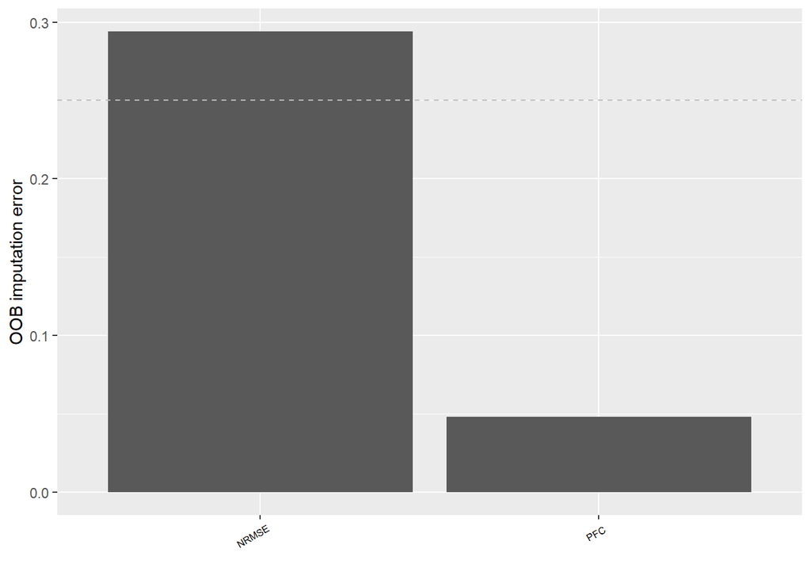

```r
                                  #0.14 (for explanatory categorical variables)


p <- ggplot2::ggplot(data = mimperr, aes(x =columns, y = errors)) +
  geom_bar(stat="identity") +
  theme(axis.text.x = element_text(color = "black", size=6, angle=30, vjust=.8, hjust=0.8)) +
  geom_hline(yintercept=0.25, linetype="dashed", color = "gray") +
  ylab("OOB imputation error") + xlab("")
p
```

```r
rm(p)
```

Note that the NRMSE measures the error of numeric variables, while the PFC measures the error of categorical variables.  
## Averaging the imputed values

Get together imputed dataset from 50 imputations.

```r
# add an ID column for merging to each dataset (each element of the list)
add_ID_col <- function(x) data.frame(ID = factor(seq(1, nrow(x))), x) # create function to use in lapply
impvals <- lapply(impvals, FUN = add_ID_col)
rm(add_ID_col) # remove function (single usage)

X <- do.call(rbind, impvals)
X <- data.table::as.data.table(X)
X[, (numcols) := lapply(.SD, as.numeric), .SDcols = numcols]
# aggregating the 50 imputed values together
Y_num <- X[, lapply(.SD, mean, na.rm=T), .SDcols = numcols, by = ID] # take mean for numeric values
# factors
faccols <- colnames(X)[!colnames(X) %in% c(numcols, "ID")]
find_most_frequent_category <- function(x){
  res <- x[which(x == names(which.max(table(x))))[1]]
  return(res)
}
Y_fac <- X[, lapply(.SD, find_most_frequent_category), .SDcols = faccols, by = ID]
rm(find_most_frequent_category)

# combine dataset to mixed data type
Y <- merge(Y_num, Y_fac, by = "ID", all = T)
Y <- data.table::data.table(Y)
#TODO remove participant ID (if wanted)
Y[, ID := NULL]

if(variables_to_include == "explanatory"){
  saveRDS(Y, "ImputationResults/clean_imputed_explanatory_dataset.rds")
}

if(variables_to_include == "response"){
 saveRDS(Y, "ImputationResults/clean_imputed_response_dataset.rds")
}


rm(Y_num); rm(Y_fac)
```

## Visual check

### numeric variables

```r
numimpcols <- names(which(apply(naloc, 2, sum) > 0))
numimpcols <- numimpcols[which(numimpcols  %in% numcols)]
# visualize imputation accuracy by column:
# Is a given missing value always filled by the same category?

numimplist <- list()
for(i in 1:length(numimpcols)){
  n <- numimpcols[i]
  print(n)
  # impossible to plot all imputed categories for all missing values.
  # draft solution : randomly chose one of the imputed values and
  # show all 50 rounds for this one.
  id <- sample(which(naloc[, which(colnames(naloc) == n)]), 1)

  temp_backup_dataset <- data.table(variable = rep(n, nrow(dataset_raw_backup)), value = dataset_raw_backup[, n])
  colnames(temp_backup_dataset)[2] <- "value"

  p <- ggplot(temp_backup_dataset,
         aes(y = variable, x = value)) +
    geom_violin() +
    geom_point(data = data.table(value = X[ID == id, get(n)], variable = n),
               position = position_jitter(),
               aes(y = variable, x = value)) +
    # geom_point(aes(x = mean(X[ID == id, get(n)]), y = n, colour = "red")) +
    theme(legend.position="none") +
    labs(title = paste(c(n, " , ID :", id), collapse = ""))

  numimplist[[i]] <- p
}
rm(temp_backup_dataset, i, id, p, n)

pdf(file = "ImputationResults/explanatory_imputation__numeric_random_ID.pdf")
plot_grid(plotlist = numimplist, nrow = 2)
```

### categorical variables

```r
facimpcols <- names(which(apply(naloc, 2, sum) > 0)) # factor columns where some of the values were missing
facimpcols <- facimpcols[which(facimpcols  %in% faccols)]
# visualise imputation accuracy by column:
# Is a given missing value always filled by the same category?
if(variables_to_include == "explanatory"){
pdf("ImputationResults/explanatory_imputation_factors_random_ID.pdf", paper = "a4r")
}

if(variables_to_include == "response"){
pdf("ImputationResults/response_imputation_factors_random_ID.pdf", paper = "a4r")
}
par(mfrow = c(3, 3))
for(f in facimpcols){
  # impossible to plot all imputed categories for all missing values.
  # draft solution : randomly chose one of the imputed values and
  # show all 50 rounds for this one.
  id <- sample(which(naloc[, which(colnames(naloc) == f)]), 1)

  plot(table(X[ID == id, get(f)]),
       main = paste(f, ", ID : ", id, sep = ""))
}
# purpose of this graph : get an idea of the imputation of categories --> do we get the same
# category for a given value across all 50 imputation rounds, or not?
# Rough idea : We select for each of the colums one ID randomly and visualise the 50
# values which were used to fill. Histogram. If one of the categories clearly dominates -->
# good sign.

rm(facimpcols); rm(f)
```

## correlations

Check correlations after imputation (use same code as above)

### for a dataset with mixed type of data

```r
#removing auxillary variables to see correlation on only those variables we later use in analysis
explanatory_variables <- strsplit("Location, Caste, House.Material, Gender, Age, Farmpc, Occupation, Nature, Ladder, EnoughFood, EnoughIncome, LandPrice, tlu, Healthy, WaterShortage, EnergySuff, ElectricitySuff, Education, Drr", split = ", ")[[1]]

if(variables_to_include == "explanatory"){
Y_subset <- Y[, ..explanatory_variables]
}
if(variables_to_include == "response"){
Y_subset <- Y
}

maindata_cor <- hetcor(Y_subset, use = "pairwise.complete.obs") # takes some time


if(variables_to_include == "explanatory"){
  pdf(file = "ImputationResults/correlations_after_imp_onlyexplanatory.pdf")
}

if(variables_to_include == "response"){
  pdf(file = "ImputationResults/correlations_after_imp_response.pdf")
}

corrplot(maindata_cor$correlations, method = "circle", type = "lower",
         tl.col = "black", tl.srt = 45, diag = T, tl.cex = 0.4)


dev.off()
```

```r
rm(Y_subset)
```

# clean

```r
# clean a bit
rm(corrdataset_raw, dataset_raw_backup, imvals, mimperr, naloc, numimplist, OOB_NRMSE, Y, X, negative, numcols, numimpcols, faccols, variables_to_include)
```